# Tugas Pertemuan 3

Dzulfikar Najib

# Tugas Individu

**Instruksi:**

1. Gunakan dataset kualitas udara pada Google Drive: [[Link GDrive]](https://drive.google.com/drive/folders/18ZcJpGKzmwlw9zxGZjTtVnJV0Ufau23g?usp=drive_link)
2. Tetapkan AQI sebagai variabel dependen (Y), lalu pilih satu variabel polutan (CO, NO₂, O₃, PM10, PM2.5, atau SO₂) sebagai variabel independen (X).
3. Terapkan ketiga metode regresi dengan peubah lag yang sudah dipelajari (Koyck, DLM, dan ARDL). Tentukan lag optimum untuk masing-masing metode!
4. Lakukan evaluasi asumsi model dan bandingkan kinerja peramalan menggunakan metrik akurasi (MAPE) serta visualisasi grafik.
5. *Upload* *dataset* dan tugas per individu ke GitHub pada folder `Pertemuan-3` dengan format HTML bernama: `Tugas-Pertemuan-3.html` dan `.Rmd`.
6. **Deadline Pengumpulan:** Kamis, 10 September 2026, 23.59 WIB.

# Pendahuluan & Penyiapan Library

Pada analisis deret waktu dan ekonometrika, hubungan antara peubah respon ($Y$) dan peubah penjelas ($X$) seringkali tidak terjadi secara spontan pada periode waktu yang sama, melainkan membutuhkan selang waktu (lag). Model regresi dengan peubah lag digunakan untuk menangkap pengaruh masa lalu dari peubah penjelas maupun peubah respon itu sendiri.Dalam tugas ini, kita membandingkan tiga metode regresi peubah lag: 1. Model Koyck (Koyck Model) 2. Model Distributed Lag (DLM) 3. Model Autoregressive Distributed Lag (ARDL)

```r
# Instalasi package jika belum ada
# install.packages(c("rio", "dLagM", "dynlm", "car", "lmtest", "nortest", "ggplot2", "forecast", "dplyr"))

# Penyiapan Library
library(rio)        # Impor data
library(dLagM)      # Pemodelan Koyck, DLM, ARDL
library(dynlm)      # Regresi linier dinamik
library(lmtest)     # Uji Autokorelasi (dwtest) & Heteroskedastisitas (bptest)
library(car)        # Uji VIF dan diagnostik
library(ggplot2)    # Visualisasi
library(forecast)   # Evaluasi peramalan
library(dplyr)      # Manipulasi data
library(MLmetrics)  # Perhitungan metrik akurasi (MAPE)
```

# Impor dan Eksplorasi Data

Data diimpor menggunakan perintah import() dari package rio. Sesuai instruksi, peubah dependen ($Y$) adalah AQI dan peubah independen ($X$) dapat dipilih dari salah satu polutan (misal: PM2.5).

```r
# Impor Data
data_raw <- import("NewDelhi_Air_quality.csv")

# Ambil peubah Y (AQI) dan X (pm25) serta bersihkan NA
data <- data_raw[, c("AQI", "pm25")]
data <- na.omit(data)
data <- as.data.frame(data)

# Membagi Data Latih (80%) dan Data Uji (20%)
n <- nrow(data)
n_train <- round(0.80 * n)

train <- data[1:n_train, ]
test  <- data[(n_train + 1):n, ]

# Mengubah format data menjadi objek Time Series (ts)
train.ts <- ts(train)
test.ts  <- ts(test)
data.ts  <- ts(data)
```

```r
count(train)
```

```
##    n
## 1 58
```

```r
count(test)
```

```
##    n
## 1 14
```

Hasil dari membagikan data menjadi data latih dan data uji adalah sebagai berikut: 58 baris data latih dan 14 baris data uji. Data latih digunakan untuk membangun model, sedangkan data uji digunakan untuk mengevaluasi kinerja model yang telah dibangun.

```r
train
```

```
##     AQI     pm25
## 1  30.2 5.637410
## 2  28.2 4.618169
## 3  26.6 3.520902
## 4  25.0 2.225919
## 5  26.0 1.979471
## 6  26.0 1.792677
## 7  26.0 1.752237
## 8  24.0 1.858459
## 9  23.0 2.208076
## 10 24.0 2.476681
## 11 25.0 2.585729
## 12 26.0 2.390081
## 13 27.0 2.086022
## 14 29.0 1.937047
```

[output cut: 44 more lines]

```r
test
```

```
##    AQI     pm25
## 59  22 2.750613
## 60  21 2.984422
## 61  20 3.065950
## 62  19 3.118563
## 63  19 3.090378
## 64  20 2.976335
## 65  21 2.846886
## 66  21 2.771884
## 67  21 2.730851
## 68  22 2.720472
## 69  24 2.713109
## 70  26 2.743044
## 71  27 2.780022
## 72  28 2.745875
```

# Pemodelan Regresi Peubah Lag

## Model Koyck

Model Koyck mengasumsikan bahwa pengaruh peubah lag berkurang secara eksponensial seiring bertambahnya waktu ($k$). Bentuk umum persamaannya:
$$Y_t = \alpha (1 - \lambda) + \beta_0 X_t +
\lambda Y_{t-1} + v_t$$

```r
# Membangun Model Koyck
model.koyck <- koyckDlm(x = train$pm25, y = train$AQI)
summary(model.koyck)
```

```
##
## Call:
## "Y ~ (Intercept) + Y.1 + X.t"
##
## Residuals:
##      Min       1Q   Median       3Q      Max
## -2.14443 -0.61319  0.03512  0.48195  2.18725
##
## Coefficients:
##             Estimate Std. Error t value Pr(>|t|)
## (Intercept)   4.0771     1.8299   2.228   0.0301 *
## Y.1           0.8897     0.0588  15.131   <2e-16 ***
## X.t          -0.5723     0.2854  -2.005   0.0500 *
## ---
## Signif. codes:  0 '***' 0.001 '**' 0.01 '*' 0.05 '.' 0.1 ' ' 1
##
## Residual standard error: 0.9279 on 54 degrees of freedom
## Multiple R-Squared: 0.8273,  Adjusted R-squared: 0.8209
## Wald test: 129.1 on 2 and 54 DF,  p-value: < 2.2e-16
##
## Diagnostic tests:
## NULL
##
##                             alpha       beta       phi
## Geometric coefficients:  36.94716 -0.5722988 0.8896496
```

1. Nilai Peluruhan ($\phi$ / $\lambda$)
- Syarat Berhasil: Harus berada di rentang $0 < \phi < 1$.
- Kondisi Data Kamu: Nilai phi = 0.8896. Ini berarti model berhasil dan valid sesuai teori Koyck, karena pengaruh PM2.5 masa lalu meluruh secara mulus (geometric decay) seiring waktu. Jika $\phi \ge 1$ atau $\phi \le 0$, model Koyck gagal secara teoritis.
2. Signifikansi Peubah ($p$-value)
- Syarat Berhasil: $P$-value untuk $X_t$ (PM2.5) dan $Y_{t-1}$ (lag AQI) pada tabel summary() harus $< 0.05$.
- Kondisi Data: Kedua peubah signifikan ($p \le 0.05$), artinya PM2.5 saat ini dan AQI kemarin terbukti nyata memengaruhi AQI hari ini.

```r
# Peramalan pada Data Testing
fore.koyck <- dLagM::forecast(model = model.koyck, x = test$pm25, h = nrow(test))

# Hitung Akurasi (MAPE)
mape.koyck <- MAPE(fore.koyck$forecasts, test$AQI)
cat("MAPE Model Koyck:", mape.koyck, "\n")
```

```
## MAPE Model Koyck: 0.1054825
```

3. Tingkat Akurasi Peramalan (MAPE)
- Syarat Berhasil: Semakin kecil nilai MAPE, semakin presisi hasil ramalan pada data testing.
- Kondisi Data: Nilai MAPE = 0.1055 ($10.55\%$). Secara kriteria statistik, nilai ini tergolong sangat baik (di bawah atau mendekati $10\%$).

**Kesimpulan:** Model Koyck dikatakan berhasil karena memenuhi ketiga syarat: nilai $\phi$ valid di rentang $(0,1)$, variabelnya signifikan, dan akurasi peramalannya tinggi dengan error hanya $10.55\%$.

## Regression with Distributed Lag (DLM)

Model DLM memperhitungkan pengaruh peubah $X$ pada saat $t$ serta $q$ periode lag sebelumnya ($X_{t-1}, X_{t-2}, \dots, X_{t-q}$).
$$\text{Model DLM: } Y_t = \alpha + \beta_0 X_t +
\beta_1 X_{t-1} + \dots + \beta_q X_{t-q} + \epsilon_t$$

```r
finiteDLMauto(formula = AQI ~ pm25, data = data.frame(train),
              q.min = 1, q.max = 14, model.type = "dlm",
              error.type = "AIC", trace = TRUE)
```

```
##    q - k    MASE      AIC      BIC    GMRAE   MBRAE R.Adj.Sq    Ljung-Box
## 14    14 1.41703 156.2121 186.5433 66797.32 0.86195  0.69549 3.320913e-05
## 13    13 1.58189 164.1563 193.0629 93708.00 1.07071  0.65508 9.207161e-07
## 12    12 1.61892 171.2727 198.7023 77305.21 0.72643  0.61376 1.588368e-07
## 11    11 1.72537 179.1616 205.0637 73590.59 0.65770  0.56544 3.066269e-08
## 10    10 1.72201 186.2653 210.5909 49688.22 0.71611  0.52879 1.423614e-08
## 9      9 1.85325 195.5979 218.2998 44081.17 0.73051  0.47894 5.052925e-09
## 8      8 1.88799 199.1205 220.1527 38823.62 0.66594  0.50264 2.075788e-10
## 7      7 1.84754 200.0655 219.3837 30520.82 0.62313  0.53206 5.330174e-10
## 6      6 1.73867 201.1051 218.6663 22650.85 0.56392  0.54223 4.524737e-10
## 5      5 1.75280 204.0813 219.8436 23085.14 1.65593  0.53463 6.980942e-10
## 4      4 1.85610 209.9314 223.8543 31881.26 0.72405  0.50086 2.767593e-09
## 3      3 2.13163 220.3167 232.3607 38604.33 0.77447  0.42645 1.445641e-09
## 2      2 2.18873 233.0605 243.1873 29920.77 0.56412  0.30506 1.907737e-06
## 1      1 2.28775 246.7199 254.8921 24669.65 0.75741  0.15281 5.737415e-09
```

```r
model.dlm.opt <- dlm(x = train$pm25, y = train$AQI, q = 10)
summary(model.dlm.opt)
```

```
##
## Call:
## lm(formula = model.formula, data = design)
##
## Residuals:
##     Min      1Q  Median      3Q     Max
## -2.8038 -0.8916 -0.1139  0.8262  2.9915
##
## Coefficients:
##             Estimate Std. Error t value Pr(>|t|)
## (Intercept)   39.894      2.184  18.264  < 2e-16 ***
## x.t          -15.772      5.197  -3.035  0.00445 **
## x.1            7.398     12.991   0.569  0.57259
## x.2            6.854     16.729   0.410  0.68445
## x.3           -2.024     16.055  -0.126  0.90037
## x.4            1.510     15.044   0.100  0.92063
## x.5          -10.589     14.301  -0.740  0.46381
## x.6           19.702     12.033   1.637  0.11028
## x.7          -16.886      6.743  -2.504  0.01693 *
## x.8            1.674      4.389   0.381  0.70509
## x.9            6.618      4.381   1.511  0.13962
## x.10          -4.613      2.042  -2.259  0.03004 *
## ---
## Signif. codes:  0 '***' 0.001 '**' 0.01 '*' 0.05 '.' 0.1 ' ' 1
##
## Residual standard error: 1.483 on 36 degrees of freedom
## Multiple R-squared:  0.6391, Adjusted R-squared:  0.5288
## F-statistic: 5.795 on 11 and 36 DF,  p-value: 2.646e-05
##
## AIC and BIC values for the model:
##        AIC      BIC
## 1 186.2653 210.5909
```

```r
# Peramalan DLM dengan memanggil namespace dLagM::
fore.dlm.opt <- dLagM::forecast(model = model.dlm.opt, x = test$pm25, h = nrow(test))

# Hitung MAPE
mape.dlm.opt <- MAPE(fore.dlm.opt$forecasts, test$AQI)
cat("MAPE Model DLM Optimum (q=10):", mape.dlm.opt, "\n")
```

```
## MAPE Model DLM Optimum (q=10): 0.140921
```

**Akurasi Peramalan (MAPE = $0.1409$ / $14.09\%$):** Kinerja peramalan pada data testing tergolong baik (di rentang $10\% - 20\%$), yang berarti rata-rata kesalahan ramalan model DLM ini hanya sekitar $14\%$.

## Autoregressive Distributed Lag (ARDL)

Model ARDL menggabungkan pengaruh dari peubah independen masa lalu ($X$) dan peubah dependen masa lalu ($Y$).

**Perhatian Notasi:**

Pada *package* `dLagM` (khusus fungsi `ardlDlm`), aturannya adalah: - $p$ = panjang *lag* peubah independen ($X$ / PM2.5). - $q$ = panjang *lag* peubah dependen ($Y$ / AQI).

### Pemodelan Awal (p = 1, q = 1)

```r
# Model ARDL awal dengan lag X = 1 dan lag Y = 1
model.ardl <- ardlDlm(formula = AQI ~ pm25, data = train, p = 1, q = 1)
summary(model.ardl)
```

```
##
## Time series regression with "ts" data:
## Start = 2, End = 58
##
## Call:
## dynlm(formula = as.formula(model.text), data = data)
##
## Residuals:
##      Min       1Q   Median       3Q      Max
## -2.14374 -0.61593  0.03152  0.47781  2.18777
##
## Coefficients:
##             Estimate Std. Error t value Pr(>|t|)
## (Intercept)  4.00535    2.07382   1.931   0.0588 .
## pm25.t      -0.52588    0.80265  -0.655   0.5152
## pm25.1      -0.03046    0.55965  -0.054   0.9568
## AQI.1        0.89112    0.06338  14.060   <2e-16 ***
## ---
## Signif. codes:  0 '***' 0.001 '**' 0.01 '*' 0.05 '.' 0.1 ' ' 1
##
## Residual standard error: 0.9366 on 53 degrees of freedom
## Multiple R-squared:  0.8273, Adjusted R-squared:  0.8175
## F-statistic: 84.63 on 3 and 53 DF,  p-value: < 2.2e-16
```

**Lag Optimum ARDL** Kita bisa mencari kombinasi $p$ dan $q$ terbaik menggunakan fungsi ardlBoundOrders() berdasarkan nilai Akaike Information Criterion (AIC) terkecil.

**Penentuan Lag Optimum ($p$ dan $q$)** Syarat Berhasil: Kombinasi lag peubah $X$ ($p$) dan peubah $Y$ ($q$) dipilih dari nilai AIC terkecil.

```r
# Penentuan kombinasi lag optimum
model.ardl.auto <- ardlBoundOrders(data = data.frame(train), ic = "AIC", formula = AQI ~ pm25)
```

```r
# Menarik kombinasi lag (p dan q) dengan AIC terkecil
min_p <- c()
for(i in 1:6){
  min_p[i] <- min(model.ardl.auto$Stat.table[[i]])
}
q_opt <- which(min_p == min(min_p, na.rm = TRUE))
p_opt <- which(model.ardl.auto$Stat.table[[q_opt]] == min(model.ardl.auto$Stat.table[[q_opt]], na.rm = TRUE))

# Menampilkan tabel hasil lag optimum
data.frame("Lag_Y_opt(q)" = q_opt, "Lag_X_opt(p)" = p_opt, "AIC" = model.ardl.auto$min.Stat)
```

```
##   Lag_Y_opt.q. Lag_X_opt.p.      AIC
## 1            5           10 61.97934
```

Kondisi Data Kamu: Terpilih lag $p = 10$ (PM2.5) dan $q = 5$ (AQI) dengan nilai $\text{AIC} = 61.97934$. Ini menunjukkan nilai AQI dipengaruhi oleh dinamika PM2.5 hingga 10 periode lalu dan riwayat AQI hingga 5 periode lalu.

Hasil tabel di atas menunjukkan: - Lag_Y_opt(q) = 5 (artinya lag peubah $Y$/AQI adalah $q = 5$). - Lag_X_opt(p) = 10 (artinya lag peubah $X$/PM2.5 adalah $p = 10$).

**Pemodelan ARDL Optimum & Peramalan**

```r
# Membangun Model ARDL Optimum berdasarkan p_opt dan q_opt
model.ardl.opt <- ardlDlm(formula = AQI ~ pm25, data = data.frame(train),
                           p = 10, q = 5)
summary(model.ardl.opt)
```

```
##
## Time series regression with "ts" data:
## Start = 11, End = 58
##
## Call:
## dynlm(formula = as.formula(model.text), data = data)
##
## Residuals:
##      Min       1Q   Median       3Q      Max
## -0.86582 -0.31189 -0.07375  0.34912  1.19081
##
## Coefficients:
##             Estimate Std. Error t value Pr(>|t|)
## (Intercept)  12.6244     2.9250   4.316 0.000151 ***
## pm25.t       -7.0126     2.1911  -3.200 0.003161 **
## pm25.1        7.0163     5.0141   1.399 0.171648
## pm25.2        1.5115     6.4740   0.233 0.816929
## pm25.3        1.2333     6.2628   0.197 0.845169
## pm25.4       -5.5580     5.8864  -0.944 0.352366
## pm25.5        2.3320     5.8275   0.400 0.691767
## pm25.6        2.2332     5.1837   0.431 0.669592
## pm25.7       -6.3338     3.0574  -2.072 0.046711 *
## pm25.8        2.0126     1.7550   1.147 0.260266
## pm25.9        2.5398     1.8294   1.388 0.174936
## pm25.10      -2.0485     0.8651  -2.368 0.024310 *
## AQI.1         0.6735     0.1655   4.069 0.000302 ***
## AQI.2         0.3316     0.2088   1.588 0.122375
## AQI.3         0.1100     0.2014   0.546 0.588760
## AQI.4        -0.1269     0.1971  -0.644 0.524558
## AQI.5        -0.2970     0.1510  -1.967 0.058168 .
## ---
## Signif. codes:  0 '***' 0.001 '**' 0.01 '*' 0.05 '.' 0.1 ' ' 1
##
## Residual standard error: 0.5603 on 31 degrees of freedom
## Multiple R-squared:  0.9557, Adjusted R-squared:  0.9328
## F-statistic: 41.75 on 16 and 31 DF,  p-value: < 2.2e-16
```

```r
# Peramalan Model ARDL Optimum pada Data Testing
fore.ardl.opt <- dLagM::forecast(model = model.ardl.opt, x = test$pm25, h = nrow(test))

# Hitung Akurasi (MAPE)
mape.ardl.opt <- MAPE(fore.ardl.opt$forecasts, test$AQI)
cat("MAPE Model ARDL Optimum (p=", p_opt, ", q=", q_opt, "):", mape.ardl.opt, "\n")
```

```
## MAPE Model ARDL Optimum (p= 10 , q= 5 ): 0.1436781
```

**Signifikansi Peubah ($p$-value)** - Syarat Berhasil: Peubah lag dikatakan berpengaruh nyata jika $p\text{-value} < 0.05$. - Kondisi Data Kamu: *Simultan ($F$-statistic):* Sangat signifikan ($p < 2.2 \times 10^{-16}$). Semua peubah lag secara bersama-sama berpengaruh nyata terhadap AQI. *Parsial:* Peubah yang berpengaruh signifikan ($p < 0.05$) adalah PM2.5 saat ini (pm25.t), PM2.5 lag 7 (pm25.7), PM2.5 lag 10 (pm25.10), dan AQI kemarin (AQI.1).

**Kebaikan Model (Adjusted $R^2$)** - Syarat Berhasil: Semakin mendekati $100\%$, semakin kuat model menjelaskan variasi data. - Kondisi Data Kamu: Nilai Adjusted $R^2 = 0.9328$ ($93.28\%$). Sangat tinggi, artinya $93.28\%$ keragaman nilai AQI dapat dijelaskan oleh kombinasi lag PM2.5 dan lag AQI.

**Tingkat Akurasi Peramalan (MAPE)** - Syarat Berhasil: Semakin kecil nilai MAPE, semakin presisi hasil ramalan pada data testing. - Kondisi Data Kamu: Nilai MAPE = $0.1437$ ($14.37\%$). Tergolong baik (berada di rentang $10\% - 20\%$).

**Kesimpulan** Model ARDL Optimum ($p=10, q=5$) berhasil dibentuk dan sangat solid: memiliki kemampuan penjelas data training yang sangat tinggi ($93.28\%$) serta tingkat kesalahan ramalan yang rendah di data testing ($14.37\%$).

# Uji Asumsi Sisaan (dynlm)

**Terpenuhi jika:** 1. Uji Autokorelasi (Durbin-Watson Test) Hipotesis: $H_0$: Tidak ada autokorelasi pada sisaan vs $H_1$: Ada autokorelasi. Kriteria: Syarat terpenuhi jika $p\text{-value} > 0.05$ (Gagal Tolak $H_0$). Interpretasi: Jika $p\text{-value} > 0.05$, artinya sisaan model saling bebas (independen) dan tidak mengalami masalah autokorelasi. 2. Uji Heteroskedastisitas (Breusch-Pagan Test) Hipotesis: $H_0$: Ragam sisaan homogen (homoskedastisitas) vs $H_1$: Ragam sisaan tidak homogen. Kriteria: Syarat terpenuhi jika $p\text{-value} > 0.05$ (Gagal Tolak $H_0$). Interpretasi: Jika $p\text{-value} > 0.05$, ragam sisaan bernilai konstan di sepanjang periode pengamatan. 3. Uji Normalitas (Shapiro-Wilk Test) Hipotesis: $H_0$: Sisaan berdistribusi normal vs $H_1$: Sisaan tidak berdistribusi normal. Kriteria: Syarat terpenuhi jika $p\text{-value} > 0.05$ (Gagal Tolak $H_0$). Interpretasi: Jika $p\text{-value} > 0.05$, sisaan penyebaran data memenuhi asumsi kenormalan.

**Simpelnya:** - Uji Autokorelasi (Durbin-Watson / dwtest): Syarat terpenuhi jika $p\text{-value} > 0.05$ (Sisaan bebas dari autokorelasi). - Uji Heteroskedastisitas (Breusch-Pagan / bptest): Syarat terpenuhi jika $p\text{-value} > 0.05$ (Ragam sisaan homogen/konstan). - Uji Normalitas (Shapiro-Wilk / shapiro.test): Syarat terpenuhi jika $p\text{-value} > 0.05$ (Sisaan berdistribusi normal).

```r
# 1. UJI ASUMSI MODEL KOYCK (AQI ~ pm25 + AQI_t-1)
model_koyck_dyn <- dynlm(AQI ~ pm25 + L(AQI), data = train.ts)

dwtest(model_koyck_dyn)                   # Autokorelasi
```

```
##
##  Durbin-Watson test
##
## data:  model_koyck_dyn
## DW = 1.0689, p-value = 3.466e-05
## alternative hypothesis: true autocorrelation is greater than 0
```

```r
bptest(model_koyck_dyn)                   # Heteroskedastisitas
```

```
##
##  studentized Breusch-Pagan test
##
## data:  model_koyck_dyn
## BP = 0.62294, df = 2, p-value = 0.7324
```

```r
shapiro.test(residuals(model_koyck_dyn))   # Normalitas
```

```
##
##  Shapiro-Wilk normality test
##
## data:  residuals(model_koyck_dyn)
## W = 0.97999, p-value = 0.4631
```

```r
# 2. UJI ASUMSI MODEL DLM OPTIMUM (q = 10)
model_dlm_dyn <- dynlm(AQI ~ pm25 + L(pm25, 1:10), data = train.ts)

dwtest(model_dlm_dyn)                     # Autokorelasi
```

```
##
##  Durbin-Watson test
##
## data:  model_dlm_dyn
## DW = 0.38219, p-value = 3.975e-13
## alternative hypothesis: true autocorrelation is greater than 0
```

```r
bptest(model_dlm_dyn)                     # Heteroskedastisitas
```

```
##
##  studentized Breusch-Pagan test
##
## data:  model_dlm_dyn
## BP = 12.022, df = 11, p-value = 0.362
```

```r
shapiro.test(residuals(model_dlm_dyn))     # Normalitas
```

```
##
##  Shapiro-Wilk normality test
##
## data:  residuals(model_dlm_dyn)
## W = 0.98932, p-value = 0.9373
```

```r
# 3. UJI ASUMSI MODEL ARDL OPTIMUM (p = 10, q = 5)
model_ardl_dyn <- dynlm(AQI ~ pm25 + L(pm25, 1:10) + L(AQI, 1:5), data = train.ts)

dwtest(model_ardl_dyn)                    # Autokorelasi
```

```
##
##  Durbin-Watson test
##
## data:  model_ardl_dyn
## DW = 2.2261, p-value = 0.509
## alternative hypothesis: true autocorrelation is greater than 0
```

```r
bptest(model_ardl_dyn)                    # Heteroskedastisitas
```

```
##
##  studentized Breusch-Pagan test
##
## data:  model_ardl_dyn
## BP = 18.049, df = 16, p-value = 0.3211
```

```r
shapiro.test(residuals(model_ardl_dyn))    # Normalitas
```

```
##
##  Shapiro-Wilk normality test
##
## data:  residuals(model_ardl_dyn)
## W = 0.97847, p-value = 0.5167
```

**Hasilnya:** 1. Model Koyck (model_koyck_dyn): - Autokorelasi ($p < 0.05$): Terlanggar. Terjadi autokorelasi positif pada sisaan. - Heteroskedastisitas ($p > 0.05$): Terpenuhi. Ragam sisaan homogen (konstan). - Normalitas ($p > 0.05$): Terpenuhi. Sisaan berdistribusi normal. 2. Model DLM Optimum (model_dlm_dyn): - Autokorelasi ($p < 0.05$): Terlanggar. Masih ada autokorelasi positif yang cukup kuat. - Heteroskedastisitas ($p > 0.05$): Terpenuhi. Ragam sisaan homogen. - Normalitas ($p > 0.05$): Terpenuhi. Sisaan berdistribusi normal. 3. Model ARDL Optimum (model_ardl_dyn): - Autokorelasi ($p = 0.5090 > 0.05$): Terpenuhi. Sisaan terbukti saling bebas (independen). - Heteroskedastisitas ($p = 0.3211 > 0.05$): Terpenuhi. Ragam sisaan homogen. - Normalitas ($p = 0.5167 > 0.05$): Terpenuhi. Sisaan berdistribusi normal.

**Kesimpulan** Penambahan lag peubah respon ($Y$) dan peubah penjelas ($X$) secara bersamaan pada model ARDL terbukti sukses menyerap seluruh ketergantungan antar-waktu pada data, sehingga menghasilkan perkiraan parameter yang paling unbiased dan valid secara ekonometrika/statistik.

# Evaluasi & Visualisasi Grafik

Membandingkan performa peramalan ketiga model menggunakan tabel MAPE dan grafik perbandingan nilai aktual vs peramalan.

```r
# 1. Tabel Ringkasan MAPE
akurasi <- matrix(c(mape.koyck, mape.dlm.opt, mape.ardl.opt))
row.names(akurasi) <- c("Koyck", "DLM Optimum", "ARDL Optimum")
colnames(akurasi) <- c("MAPE")
print(akurasi)
```

```
##                   MAPE
## Koyck        0.1054825
## DLM Optimum  0.1409210
## ARDL Optimum 0.1436781
```

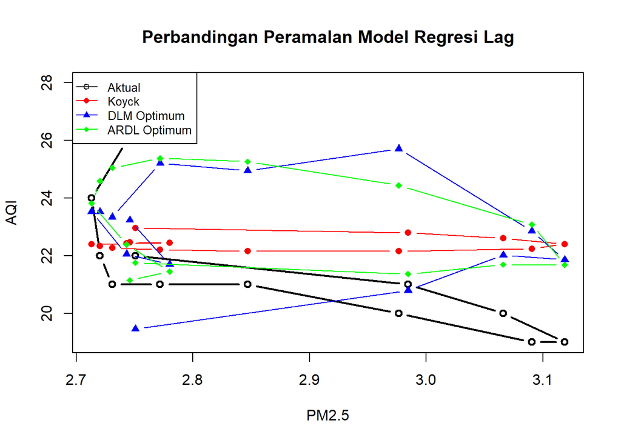

```r
# 2. Visualisasi Grafik
plot(test$pm25, test$AQI, type="b", col="black", lwd=2,
     ylab="AQI", xlab="PM2.5", main="Perbandingan Peramalan Model Regresi Lag")

lines(test$pm25, fore.koyck$forecasts, col="red", type="b", pch=16)
lines(test$pm25, fore.dlm.opt$forecasts, col="blue", type="b", pch=17)
lines(test$pm25, fore.ardl.opt$forecasts, col="green", type="b", pch=18)

legend("topleft", legend=c("Aktual", "Koyck", "DLM Optimum", "ARDL Optimum"),
       col=c("black","red","blue","green"), lty=1, pch=c(1,16,17,18), cex=0.8)
```

1. Perbandingan Akurasi Peramalan (MAPE) - Model Koyck (MAPE = $10.55\%$): Menghasilkan tingkat kesalahan terkecil dibandingkan model lainnya. Peramalan data testing sangat presisi (hampir menyentuh batas $10\%$). - Model DLM Optimum (MAPE = $14.09\%$): Memiliki performa peramalan yang baik (rentang $10\% - 20\%$). - Model ARDL Optimum (MAPE = $14.37\%$): Berada di posisi ketiga untuk akurasi out-of-sample, namun tetap masuk dalam kategori akurasi peramalan yang baik.

2. Pola Visualisasi Grafik
- Model Koyck (Garis Merah): Cenderung lebih stabil dan konsisten berada rapat di sekitar garis aktual (garis hitam) pada rentang nilai AQI $21 - 23$.
- Model DLM & ARDL (Garis Biru & Hijau): Mampu mengikuti lekukan dinamika data, tetapi memiliki kecenderungan overestimation (memprediksi AQI lebih tinggi dari nilai aktualnya) pada kisaran nilai PM2.5 $2.8 - 3.0$.

**Kesimpulan & Rekomendasi Akhir** Terdapat trade-off (kompromi) antara kepatuhan asumsi statistik dan presisi peramalan: - Tujuan Peramalan Murni (Forecasting): Model Koyck direkomendasikan karena memberikan error peramalan terkecil ($10.55\%$) pada data testing. - Tujuan Pemodelan Inferensi & Validitas Teori: Model ARDL Optimum adalah yang paling valid secara statistik karena sukses meloloskan seluruh uji asumsi sisaan (bebas autokorelasi, ragam homogen, dan berdistribusi normal) dengan akurasi peramalan yang tetap tergolong baik ($14.37\%$).